# NYC Bike Analysis

Lauren Davidson

18/01/2021

# Introduction to the data

A dataset sourced from New York Citi Bikes made available via the open source Tsibble Data package. The dataset contains the rental information of 10 bikes throughout 2018. It is important to consider whether these journeys are representative of overall Citi bike usage. We know that the data has been processed to remove non-representative data such as rides taken by members of Citi Bike staff or ‘false start’ journeys lasting less than 60 seconds. If we assume that the 10 bikes have been selected at random, then tracking 10 of the Citi Bike’s fleet of 15,000 bike should provide a useful cross-section of use. Though we might find that these bikes are not used evenly across the entire city as their location is dependent on customer usage. A larger sample would provide stronger evidence. While we have access to the start and end point of the journey and the customer’s birth year and gender, we will not be able to identify individual users, so there is no concern about privacy. Indeed, attempting to identify individual users is prohibited under the Citi Bike Data License Agreement.

# Analysis Questions

#### What is the pattern of bike hires over time (e.g. within a year, month, week, or day)?

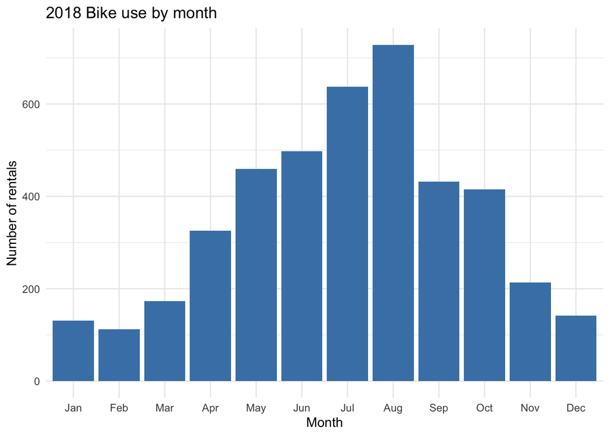

This information can be used by Citi Bikes to increase advertising in months where we see a decline in usage - February, November and December. Citi Bikes could also consider how they can have the largest possible fleet active in May-August, by increasing bike maintenance during these months and scheduling maintenance which requires removal form the road during December.

#### Do bike hire patterns differ between bike rider demographics? (e.g. gender, type of trip, age)

###### Time of usage

No relationship identified between start time and gender, start time and age or start time and subscription status.

###### Trip length

We do not see a clear relationship between age and trip length. Though it there is some indication that the oldest and youngest users have the longest trip times.

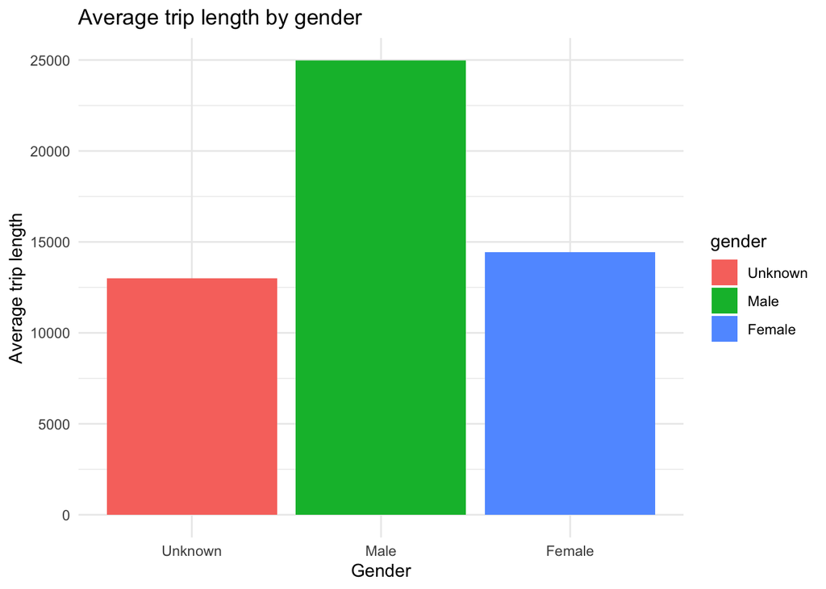

From this graph we see that male users have a longer average journey time than women and undisclosed genders.

From this and the user base being greater for men than for women, it seems that Citi Bike may want to invest time and research into why women are not using the Citi Bikes to the same extent as men. Are the bikes comfortable for women? Is the advertising or aesthetic of the bikes more attractive to men than to women?

#### What is the geographical spread of the start points of bike hires?

[interactive chart not shown]

All of the rentals in our dataset which start at the peak hours, 8am and 6pm, are located close to Jersey City. Note that this information may be an effect of the bicycles included in our sample rather than indicative of city wide usage.

If this pattern were confirmed with additional data, Citi Bikes could use this information to ensure that they have bikes available in the right places. They might also consider advertising or testing new distribution in under-utilised areas such as Manhattan.

#### Any other insights?

##### Proportion of users by gender, age and subscription status

In our sample, 77% of users with a disclosed gender are male.

In New York City, at least 50% of the population is female, so this number suggests that Citi Bikes are missing out on a potential customer base. I recommend testing this by collecting a further sample as Citi Bikes may increase hire numbers by targetting female customers.

92% of Citi Bike hires are conducted by subscribers.

85% of Citi Bike users are under 30.

##### Journey start time

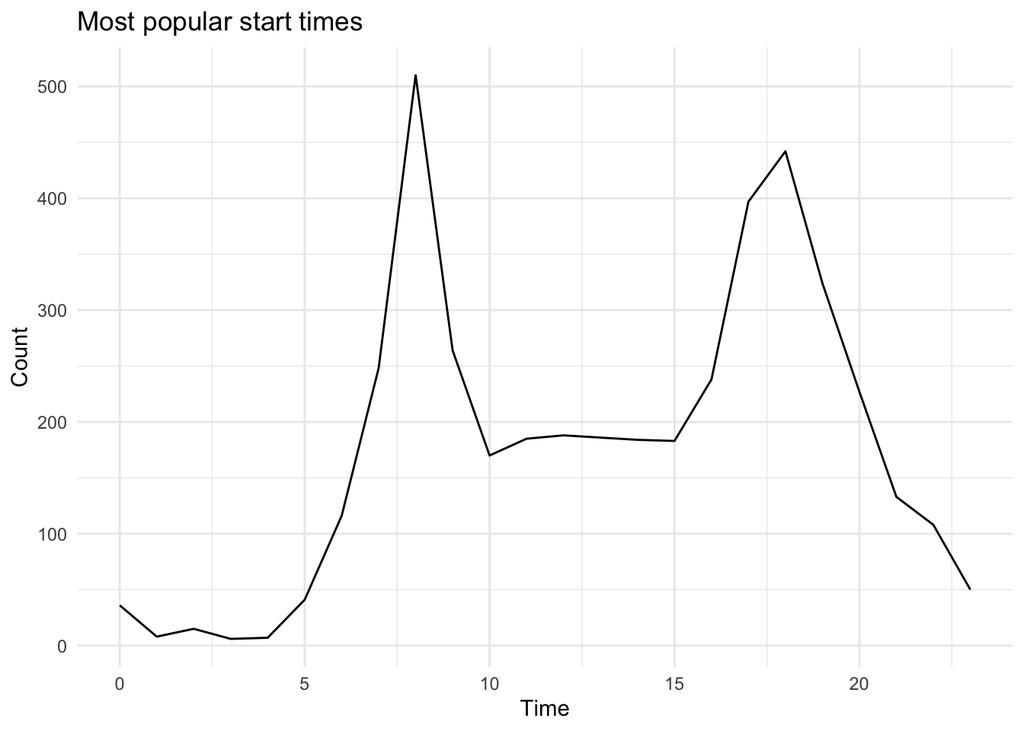

This graph shows us two peaks for the start time of journeys, at 8am and 6pm.

Citi Bikes may want to consider running maintenance between midnight and 5am, when demand for bikes is lowest. They might also how to ensure coverage and availability at peak times, by running small repairs and redistributing bikes between 10am and 3pm.

# Conclusions

Peak demand for bikes is from May to August annually, and at 8am and 6pm daily. Citi Bikes may increase bike hire levels by ensuring that there is sufficient availability and coverage during peak times and encouraging additional use during off-peak times through promotions or advertising.

As Citi Bikes have less female customers than male customers and the women have shorter journey lengths than men, Citi Bikes may benefit from research into the comfort of their bikes for women and the attractiveness of their branding towards women.

Citi Bikes may like to conduct further research into the start position of bike rides at epak time to ensure availability in key areas and to identify areas of the city with lower suage levels, who may benefit from targetted advertising or a rethink of station layout.